# Workshop: Introduction to Information Theory — Part 2: Coding, Channels, and Applications

Author

Mick Cooney mickcooney@gmail.com

Published

May 10, 2026

# 1 From Theory to Practice

Part 1 built the core language of information theory: entropy, mutual information, KL divergence, and cross-entropy. In Part 2, we answer the operational questions Shannon cared about:

1. How efficiently can we compress data?
2. How reliably can we transmit data over noisy channels?
3. How do these concepts drive modern machine learning and risk modelling?

# 2 Source Coding and Data Compression

## 2.1 Shannon Source Coding Theorem

For a discrete memoryless source with entropy $H(X)$ (bits/symbol), no lossless code can achieve expected length below $H(X)$ bits/symbol on average. Conversely, there exist codes with expected length arbitrarily close to $H(X)$.

For practical prefix-free codes (e.g., Huffman), average code length $L$ obeys:

$$H(X) \le L < H(X) + 1$$

That inequality is one of the most actionable facts in data compression.

In practical terms, this theorem is a feasibility check. Before choosing any algorithm, entropy tells you whether your compression target is realistic at all. If your target bit-rate is below $H(X)$ for strict lossless coding, no engineering trick can save you.

## 2.2 Building Huffman Codes from Scratch

```r
source_probs <- c(0.30, 0.20, 0.15, 0.10, 0.08, 0.07, 0.06, 0.04)
source_sym   <- LETTERS[1:length(source_probs)]

huff_tbl <- build_huffman_code(source_sym, source_probs) |>
  arrange(desc(probability))

entropy_h <- shannon_entropy(source_probs)
exp_len   <- huffman_expected_length(huff_tbl)

huff_tbl |>
  mutate(efficiency = entropy_h / exp_len) |>
  knitr::kable(digits = 4, caption = "Huffman Coding Table")
```

Huffman Coding Table

| symbol | probability | codeword | code_length | efficiency |
| --- | --- | --- | --- | --- |
| A | 0.30 | 10 | 2 | 0.9882 |
| B | 0.20 | 01 | 2 | 0.9882 |
| C | 0.15 | 110 | 3 | 0.9882 |
| D | 0.10 | 001 | 3 | 0.9882 |
| E | 0.08 | 1111 | 4 | 0.9882 |
| F | 0.07 | 1110 | 4 | 0.9882 |
| G | 0.06 | 0001 | 4 | 0.9882 |
| H | 0.04 | 0000 | 4 | 0.9882 |

Huffman codewords for a non-uniform 8-symbol source. Frequent symbols get shorter bit strings.

```r
cat(glue(
  "Source entropy H(X)         : {round(entropy_h, 4)} bits/symbol\n",
  "Expected Huffman length L   : {round(exp_len,   4)} bits/symbol\n",
  "Redundancy (L - H)          : {round(exp_len - entropy_h, 4)} bits/symbol\n",
  "Coding efficiency (H/L)     : {round(100 * entropy_h / exp_len, 2)}%\n"
))
```

```
Source entropy H(X)         : 2.7176 bits/symbol
Expected Huffman length L   : 2.75 bits/symbol
Redundancy (L - H)          : 0.0324 bits/symbol
Coding efficiency (H/L)     : 98.82%
```

### 2.2.1 Why This Matters in Practice

This table gives an immediate coding audit:

- `L - H` quantifies how much overhead your practical code pays versus the theoretical optimum.
- Efficiency close to 100% means your coding scheme is near-optimal for that source model.
- If efficiency is low, the issue is often source modeling (wrong symbols or granularity), not the code itself.

## 2.3 Visualising the Compression Bound

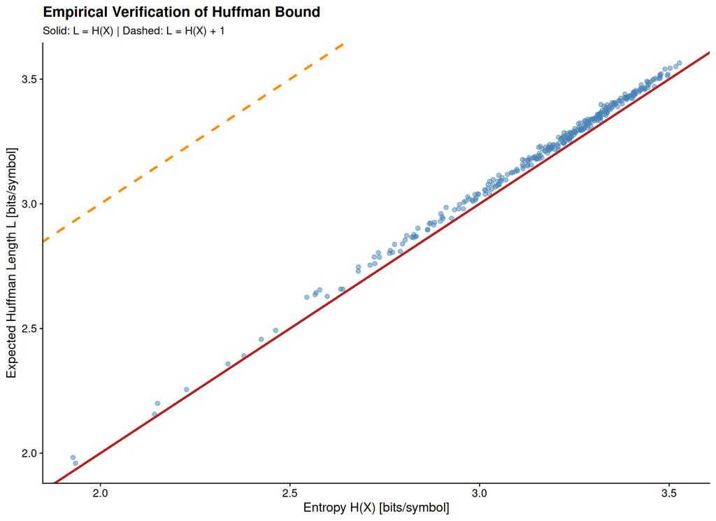

Across random sources, Huffman expected length remains tightly bounded by H(X) and H(X)+1.

```r
n_trials <- 300
k_alphabet <- 12

bound_tbl <- map_dfr(seq_len(n_trials), function(i) {
  p <- rgamma(k_alphabet, shape = runif(1, 0.5, 3), rate = 1)
  p <- p / sum(p)
  s <- paste0("s", seq_len(k_alphabet))

  h  <- shannon_entropy(p)
  hf <- build_huffman_code(s, p)
  l  <- huffman_expected_length(hf)

  tibble(trial = i, entropy = h, expected_length = l)
})

ggplot(bound_tbl, aes(x = entropy, y = expected_length)) +
  geom_point(alpha = 0.5, colour = "steelblue") +
  geom_abline(intercept = 0, slope = 1, colour = "firebrick", linewidth = 1.2) +
  geom_abline(intercept = 1, slope = 1, colour = "darkorange", linewidth = 1.2, linetype = "dashed") +
  labs(
    title    = "Empirical Verification of Huffman Bound",
    subtitle = "Solid: L = H(X) | Dashed: L = H(X) + 1",
    x        = "Entropy H(X) [bits/symbol]",
    y        = "Expected Huffman Length L [bits/symbol]"
  )
```

### 2.3.1 Why This Matters in Practice

The scatter around the lower bound is an operational expectation:

- Huffman performs very close to the entropy limit across broad source shapes.
- The remaining gap is bounded and predictable.
- This is why Huffman remains a strong baseline even when more complex codecs are available.

## 2.4 Compression Simulation on Synthetic Text

```r
simulate_text <- function(n_chars, probs, alphabet = letters) {
  sample(alphabet[seq_along(probs)], size = n_chars, replace = TRUE, prob = probs)
}

compression_experiment <- function(probs, n_chars = 10000) {
  alphabet <- letters[1:length(probs)]
  message  <- simulate_text(n_chars, probs, alphabet)

  code_tbl <- build_huffman_code(alphabet, probs)
  encoded  <- huffman_encode(message, code_tbl)

  raw_bits <- n_chars * ceiling(log2(length(alphabet)))
  cmp_bits <- nchar(encoded)

  tibble(
    entropy_bits_per_symbol = shannon_entropy(probs),
    expected_huff_len       = huffman_expected_length(code_tbl),
    raw_bits_per_symbol     = raw_bits / n_chars,
    compressed_bits_per_symbol = cmp_bits / n_chars,
    compression_ratio       = cmp_bits / raw_bits
  )
}

k <- 8
uniform_probs <- rep(1 / k, k)
moderate_skew <- c(0.30, 0.20, 0.15, 0.10, 0.08, 0.07, 0.06, 0.04)
heavy_skew    <- c(0.55, 0.20, 0.10, 0.06, 0.04, 0.025, 0.015, 0.01)

cmp_tbl <- bind_rows(
  compression_experiment(uniform_probs) |> mutate(source = "Uniform"),
  compression_experiment(moderate_skew) |> mutate(source = "Moderately skewed"),
  compression_experiment(heavy_skew)    |> mutate(source = "Heavily skewed")
)

cmp_tbl |>
  select(source, entropy_bits_per_symbol, compressed_bits_per_symbol, raw_bits_per_symbol, compression_ratio) |>
  knitr::kable(digits = 3, caption = "Compression Outcomes by Source Distribution")
```

Compression Outcomes by Source Distribution

| source | entropy_bits_per_symbol | compressed_bits_per_symbol | raw_bits_per_symbol | compression_ratio |
| --- | --- | --- | --- | --- |
| Uniform | 3.000 | 3.00 | 3 | 1.000 |
| Moderately skewed | 2.718 | 2.75 | 3 | 0.917 |
| Heavily skewed | 1.991 | 2.02 | 3 | 0.673 |

Compression ratio improves when symbol distribution is skewed (lower entropy). Uniform text is incompressible.

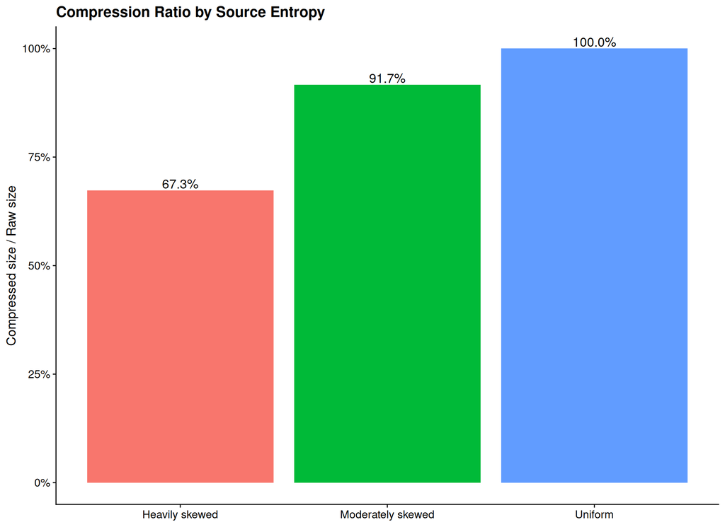

Compression ratio improves when symbol distribution is skewed (lower entropy). Uniform text is incompressible.

```r
cmp_tbl |>
  ggplot(aes(x = source, y = compression_ratio, fill = source)) +
  geom_col(show.legend = FALSE) +
  geom_text(aes(label = percent(compression_ratio, accuracy = 0.1)), vjust = -0.2) +
  scale_y_continuous(labels = label_percent()) +
  labs(
    title = "Compression Ratio by Source Entropy",
    x     = NULL,
    y     = "Compressed size / Raw size"
  )
```

### 2.4.1 Why This Matters in Practice

The simulation separates two questions that are often conflated:

- “Can I compress this at all?” (depends on entropy structure)
- “How much can I compress?” (depends on both entropy and coding method)

Uniform-like data behaves as near-incompressible noise, while skewed data contains exploitable regularity.

# 3 Noisy Channels and Capacity

## 3.1 Shannon’s Noisy Channel Theorem

For a communication channel with capacity $C$ (bits/channel use), and coding rate $R$:

- if $R < C$, there exist coding schemes with arbitrarily low error probability (as block length increases);
- if $R > C$, reliable communication is impossible.

This theorem gives a hard physical boundary between possible and impossible communication performance.

That boundary is a strategic planning tool:

- If a design rate sits above capacity, investment should go to channel quality, bandwidth, or rate reduction — not to better decoding heuristics alone.
- If rate is below capacity, coding/latency/complexity trade-offs become the main design space.

## 3.2 Binary Symmetric Channel (BSC)

The BSC flips each transmitted bit independently with probability $p$. Its capacity is:

$$C_{\text{BSC}} = 1 - H_b(p)$$

where $H_b(p) = -p\log_2 p - (1-p)\log_2(1-p)$ is binary entropy.

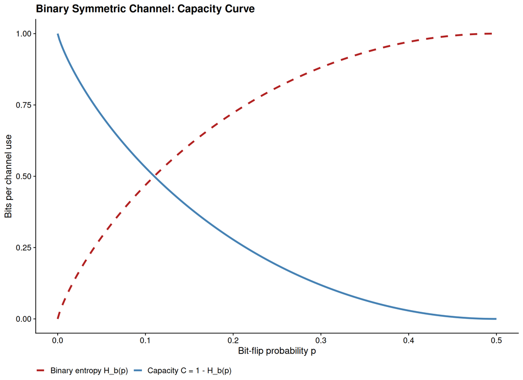

BSC capacity as a function of crossover probability p. Capacity is maximal at p=0 and drops to 0 at p=0.5.

```r
cap_tbl <- bsc_capacity_curve(seq(0, 0.5, by = 0.002))

ggplot(cap_tbl, aes(x = p_error)) +
  geom_line(aes(y = capacity, colour = "Capacity C = 1 - H_b(p)"), linewidth = 1.3) +
  geom_line(aes(y = binary_entropy, colour = "Binary entropy H_b(p)"), linewidth = 1.3, linetype = "dashed") +
  scale_colour_manual(values = c("Capacity C = 1 - H_b(p)" = "steelblue", "Binary entropy H_b(p)" = "firebrick")) +
  labs(
    title  = "Binary Symmetric Channel: Capacity Curve",
    x      = "Bit-flip probability p",
    y      = "Bits per channel use",
    colour = NULL
  ) +
  theme(legend.position = "bottom")
```

### 3.2.1 Why This Matters in Practice

The BSC curve is a direct resilience map:

- Small increases in noise near moderate $p$ can cause meaningful capacity loss.
- At $p=0.5$, the channel carries no reliable information.
- Capacity converts raw noise levels into actionable throughput limits.

## 3.3 Simulating Uncoded vs. Coded Transmission

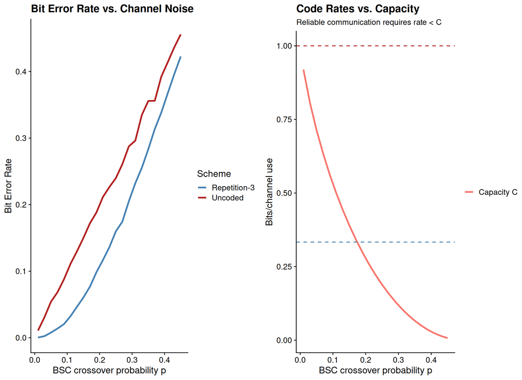

Simple repetition coding helps at low/moderate noise but wastes rate. Capacity bounds what is fundamentally possible.

```r
decode_repetition3 <- function(bits_rx) {
  mat <- matrix(bits_rx, ncol = 3, byrow = TRUE)
  as.integer(rowSums(mat) >= 2)
}

simulate_bsc_trial <- function(p_error, n_bits = 6000) {
  bits_tx <- rbinom(n_bits, size = 1, prob = 0.5)

  # Uncoded
  bits_rx_uncoded <- simulate_bsc(bits_tx, p_error)
  ber_uncoded <- mean(bits_tx != bits_rx_uncoded)

  # Repetition-3 code (rate = 1/3)
  bits_rep <- rep(bits_tx, each = 3)
  bits_rx_rep <- simulate_bsc(bits_rep, p_error)
  bits_hat_rep <- decode_repetition3(bits_rx_rep)
  ber_rep <- mean(bits_tx != bits_hat_rep)

  tibble(
    p_error = p_error,
    ber_uncoded = ber_uncoded,
    ber_rep3 = ber_rep,
    rate_uncoded = 1,
    rate_rep3 = 1/3,
    bsc_capacity = bsc_capacity(p_error)
  )
}

p_grid <- seq(0.01, 0.45, by = 0.02)
ber_tbl <- map_dfr(p_grid, ~simulate_bsc_trial(.x, n_bits = 9000))

p1_ber <- ber_tbl |>
  pivot_longer(c(ber_uncoded, ber_rep3), names_to = "scheme", values_to = "ber") |>
  mutate(scheme = recode(scheme, ber_uncoded = "Uncoded", ber_rep3 = "Repetition-3")) |>
  ggplot(aes(x = p_error, y = ber, colour = scheme)) +
  geom_line(linewidth = 1.2) +
  scale_colour_manual(values = c("Uncoded" = "firebrick", "Repetition-3" = "steelblue")) +
  labs(
    title  = "Bit Error Rate vs. Channel Noise",
    x      = "BSC crossover probability p",
    y      = "Bit Error Rate",
    colour = "Scheme"
  )

p2_rate <- ber_tbl |>
  mutate(rep3_feasible = rate_rep3 < bsc_capacity, uncoded_feasible = rate_uncoded < bsc_capacity) |>
  ggplot(aes(x = p_error)) +
  geom_line(aes(y = bsc_capacity, colour = "Capacity C"), linewidth = 1.2) +
  geom_hline(yintercept = 1/3, colour = "steelblue", linetype = "dashed") +
  geom_hline(yintercept = 1, colour = "firebrick", linetype = "dashed") +
  labs(
    title = "Code Rates vs. Capacity",
    subtitle = "Reliable communication requires rate < C",
    x = "BSC crossover probability p",
    y = "Bits/channel use",
    colour = NULL
  )

plot_grid(p1_ber, p2_rate, ncol = 2)
```

### 3.3.1 Why This Matters in Practice

This paired plot illustrates the engineering trade-off clearly:

- Lower-rate coding can reduce BER at the cost of throughput.
- Capacity contextualizes whether that trade-off is fundamentally feasible.
- A coding scheme can improve reliability but cannot violate the rate-capacity barrier.

## 3.4 Binary Erasure Channel (BEC)

The BEC erases bits with probability $\epsilon$ (receiver knows which bits are missing). Capacity is simply:

$$C_{\text{BEC}} = 1 - \epsilon$$

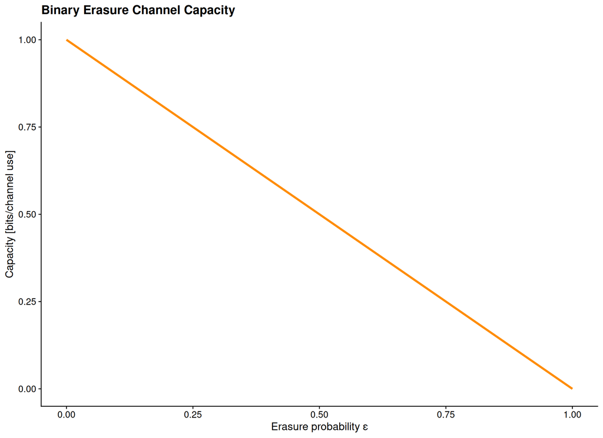

BEC has linear capacity decay: each erasure directly removes one bit of usable information.

```r
eps_grid <- seq(0, 1, by = 0.01)

bec_tbl <- tibble(
  epsilon = eps_grid,
  capacity = bec_capacity(eps_grid)
)

ggplot(bec_tbl, aes(x = epsilon, y = capacity)) +
  geom_line(colour = "darkorange", linewidth = 1.3) +
  labs(
    title = "Binary Erasure Channel Capacity",
    x     = "Erasure probability ε",
    y     = "Capacity [bits/channel use]"
  )
```

### 3.4.1 Why This Matters in Practice

BEC capacity is operationally simple and highly useful for packet-loss systems:

- Every unit of erasure probability removes the same unit of usable capacity.
- This linearity makes back-of-the-envelope design and SLA translation easy.
- It is a good first-order model for dropped frames/packets with explicit missingness indicators.

## 3.5 AWGN Channel and the Shannon-Hartley Law

For an additive white Gaussian noise channel:

$$C = B \log_2(1 + \text{SNR})$$

where $B$ is bandwidth and SNR is linear (not dB).

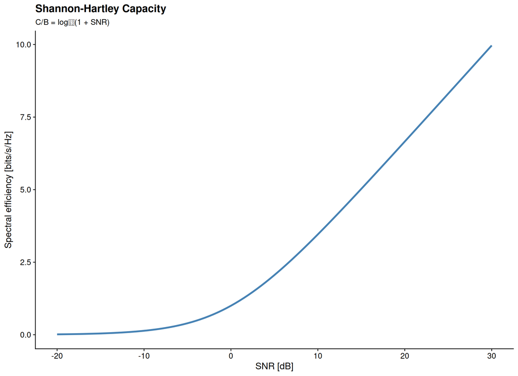

AWGN channel capacity per Hz as a function of SNR in dB.

```r
snr_db <- seq(-20, 30, by = 0.5)
snr_lin <- 10^(snr_db / 10)

awgn_tbl <- tibble(
  snr_db    = snr_db,
  snr_lin   = snr_lin,
  capacity_per_hz = awgn_capacity(snr_lin, bw = 1)
)

ggplot(awgn_tbl, aes(x = snr_db, y = capacity_per_hz)) +
  geom_line(colour = "steelblue", linewidth = 1.3) +
  labs(
    title = "Shannon-Hartley Capacity",
    subtitle = "C/B = log₂(1 + SNR)",
    x = "SNR [dB]",
    y = "Spectral efficiency [bits/s/Hz]"
  )
```

### 3.5.1 Why This Matters in Practice

The log-shape is the key planning insight:

- Early SNR gains are very valuable.
- At high SNR, returns diminish sharply.
- This helps decide whether to spend budget on power/SNR improvements or on bandwidth and coding changes.

# 4 Applied Information Theory in Machine Learning

## 4.1 Entropy and Decision Trees

Decision trees choose splits that reduce uncertainty most. In ID3/C4.5-style learning, this is **information gain**:

$$\text{IG}(Y, X_j) = H(Y) - H(Y \mid X_j)$$

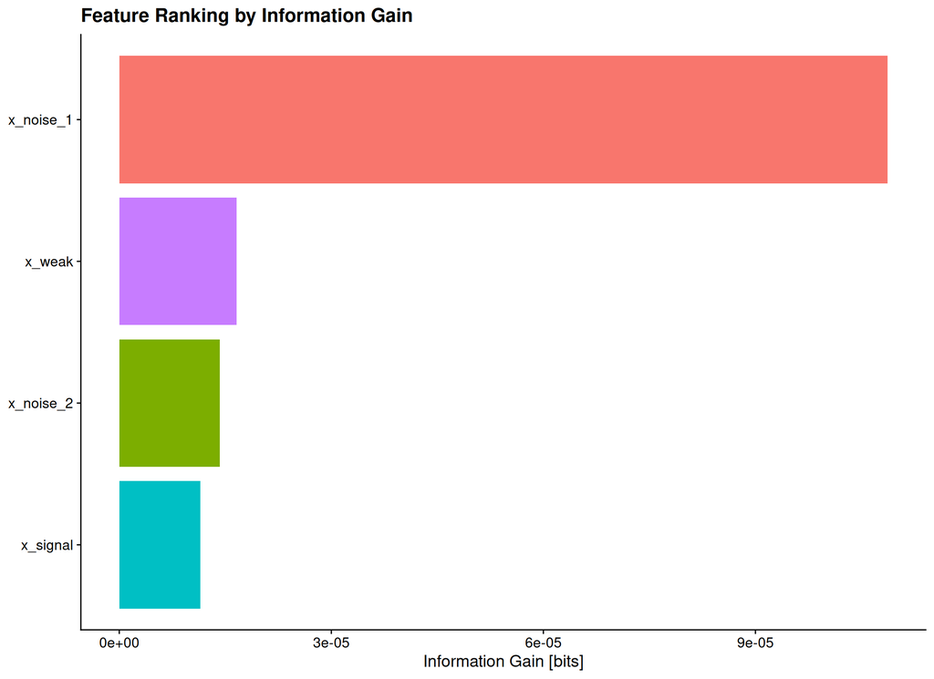

Information gain ranking for candidate features in a synthetic classification problem.

```r
set.seed(1234)
n <- 5000

x_signal  <- rbinom(n, 1, 0.5)
x_weak    <- rbinom(n, 1, 0.5)
x_noise_1 <- rbinom(n, 1, 0.5)
x_noise_2 <- rbinom(n, 1, 0.5)

# Target depends strongly on x_signal, weakly on x_weak
y <- ifelse(runif(n) < ifelse(x_signal == 1, 0.85, 0.15), 1L, 0L)
y <- ifelse(runif(n) < ifelse(x_weak == 1, 0.08, -0.08) + 0.5, y, 1L - y)

mi_feature <- function(feature, target) {
  tab <- table(feature, target)
  mutual_information(tab / sum(tab))
}

ig_tbl <- tibble(
  feature = c("x_signal", "x_weak", "x_noise_1", "x_noise_2"),
  info_gain_bits = c(
    mi_feature(x_signal, y),
    mi_feature(x_weak, y),
    mi_feature(x_noise_1, y),
    mi_feature(x_noise_2, y)
  )
) |>
  arrange(desc(info_gain_bits))

ggplot(ig_tbl, aes(x = reorder(feature, info_gain_bits), y = info_gain_bits, fill = feature)) +
  geom_col(show.legend = FALSE) +
  coord_flip() +
  labs(
    title = "Feature Ranking by Information Gain",
    x     = NULL,
    y     = "Information Gain [bits]"
  )
```

### 4.1.1 Why This Matters in Practice

Information gain is an interpretable feature utility metric:

- It quantifies uncertainty reduction in bits, not just relative score order.
- It can expose useful non-linear predictors that simple linear filters miss.
- It supports transparent feature triage before expensive model training.

## 4.2 Cross-Entropy Loss and Calibration

Cross-entropy punishes overconfident wrong predictions much more than uncertain ones. This is why modern classifiers optimise log-loss.

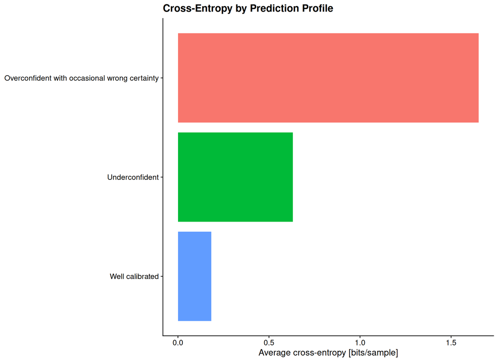

Cross-entropy penalties for different prediction quality profiles. Overconfident errors are catastrophic.

```r
n <- 4000
true_y <- rbinom(n, 1, 0.5)

# Three hypothetical models
pred_well_calib <- pmin(pmax(0.1 + 0.8 * true_y + rnorm(n, sd = 0.12), 0.001), 0.999)
pred_underconf  <- pmin(pmax(0.35 + 0.3 * true_y + rnorm(n, sd = 0.08), 0.001), 0.999)
pred_overconf_wrong <- ifelse(runif(n) < 0.15, ifelse(true_y == 1, 0.001, 0.999), pred_well_calib)

ce_loss <- function(y, p) {
  -mean(y * log2(p) + (1 - y) * log2(1 - p))
}

cal_tbl <- tibble(
  model = c("Well calibrated", "Underconfident", "Overconfident with occasional wrong certainty"),
  cross_entropy_bits = c(
    ce_loss(true_y, pred_well_calib),
    ce_loss(true_y, pred_underconf),
    ce_loss(true_y, pred_overconf_wrong)
  )
)

ggplot(cal_tbl, aes(x = reorder(model, cross_entropy_bits), y = cross_entropy_bits, fill = model)) +
  geom_col(show.legend = FALSE) +
  coord_flip() +
  labs(
    title = "Cross-Entropy by Prediction Profile",
    x     = NULL,
    y     = "Average cross-entropy [bits/sample]"
  )
```

### 4.2.1 Why This Matters in Practice

This is a calibration lesson, not just a loss-function detail:

- Models can have similar accuracy but very different decision quality.
- Overconfident mistakes are expensive in risk-sensitive systems.
- Cross-entropy is a better metric than accuracy when downstream actions depend on probability values.

## 4.3 VAE View: KL as Information Bottleneck Regulariser

In variational autoencoders, the objective includes:

$$\mathbb{E}_{q_\phi(z|x)}[-\log p_\theta(x|z)] + \beta D_{\text{KL}}\bigl(q_\phi(z|x)\|p(z)\bigr)$$

The KL term penalises latent posteriors that carry too much information, forcing compressed representations. Larger $\beta$ means stronger compression (and often lower reconstruction fidelity).

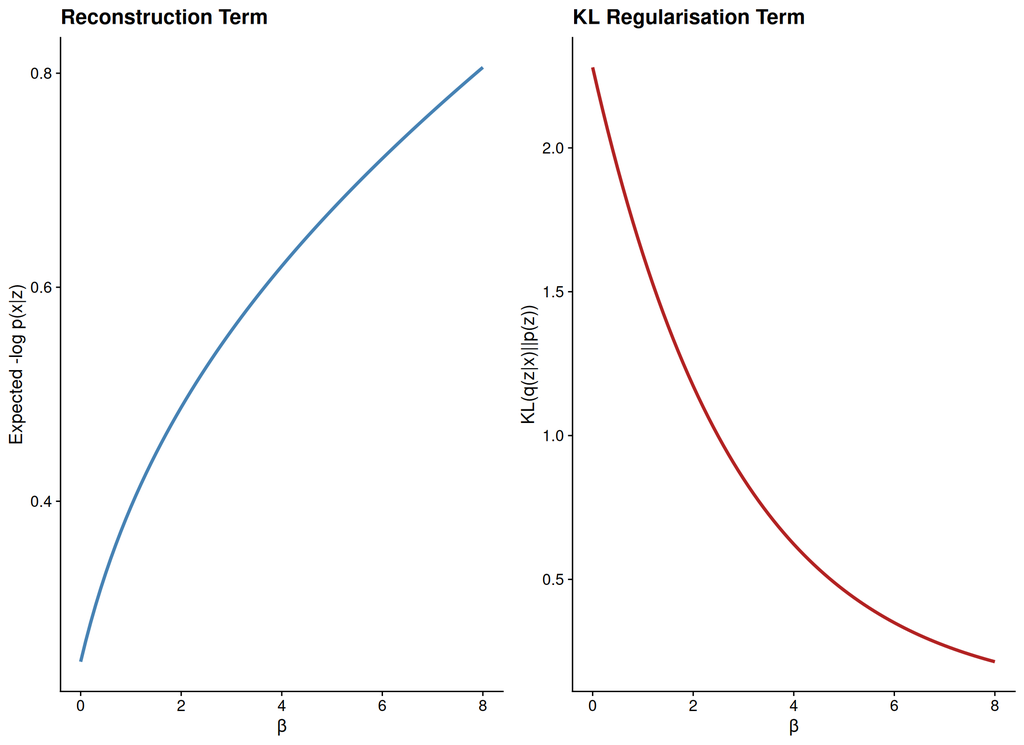

Synthetic beta-VAE style trade-off curve between reconstruction quality and KL regularisation strength.

```r
beta_grid <- seq(0, 8, by = 0.1)

# Stylised (simulated) trade-off curves for pedagogy
vae_tbl <- tibble(
  beta = beta_grid,
  recon_loss = 0.25 + 0.18 * log1p(beta) + 0.02 * beta,
  kl_term    = 2.2 * exp(-0.35 * beta) + 0.08,
  total_elbo = recon_loss + beta * kl_term
)

p_recon <- ggplot(vae_tbl, aes(x = beta, y = recon_loss)) +
  geom_line(colour = "steelblue", linewidth = 1.2) +
  labs(title = "Reconstruction Term", x = "β", y = "Expected -log p(x|z)")

p_kl <- ggplot(vae_tbl, aes(x = beta, y = kl_term)) +
  geom_line(colour = "firebrick", linewidth = 1.2) +
  labs(title = "KL Regularisation Term", x = "β", y = "KL(q(z|x)||p(z))")

plot_grid(p_recon, p_kl, ncol = 2)
```

### 4.3.1 Why This Matters in Practice

The $\beta$ dial is a practical control knob:

- Higher $\beta$ encourages simpler latent representations.
- Lower $\beta$ prioritizes reconstruction detail.
- The right value depends on whether the goal is compression, generation, disentanglement, or predictive utility.

# 5 Finance and Insurance Application

## 5.1 Mutual Information for Non-Linear Dependence in Risk Signals

Pearson correlation can miss dependence structures driven by regime switches, thresholds, or shared latent shocks. MI captures these dependencies.

Here we simulate a stylised insurance setting:

- monthly catastrophe indicator $C_t$
- claim frequency signal $F_t$
- claim severity signal $S_t$

Frequency and severity become strongly dependent during catastrophe regimes, even when linear correlation appears modest.

```r
set.seed(2026)
n_months <- 12000

cat_regime <- rbinom(n_months, 1, 0.08)

freq <- rpois(n_months, lambda = ifelse(cat_regime == 1, 12, 4))
sev  <- rgamma(n_months,
               shape = ifelse(cat_regime == 1, 2.2, 3.5),
               rate  = ifelse(cat_regime == 1, 0.0012, 0.0035))

pearson_fs <- cor(freq, sev)
mi_fs      <- estimate_mi_histogram(freq, sev, n_bins_x = 15, n_bins_y = 15)

cat(glue(
  "Pearson correlation(F, S): {round(pearson_fs, 3)}\n",
  "Mutual information(F, S): {round(mi_fs, 3)} bits\n"
))
```

```
Pearson correlation(F, S): 0.266
Mutual information(F, S): 0.062 bits
```

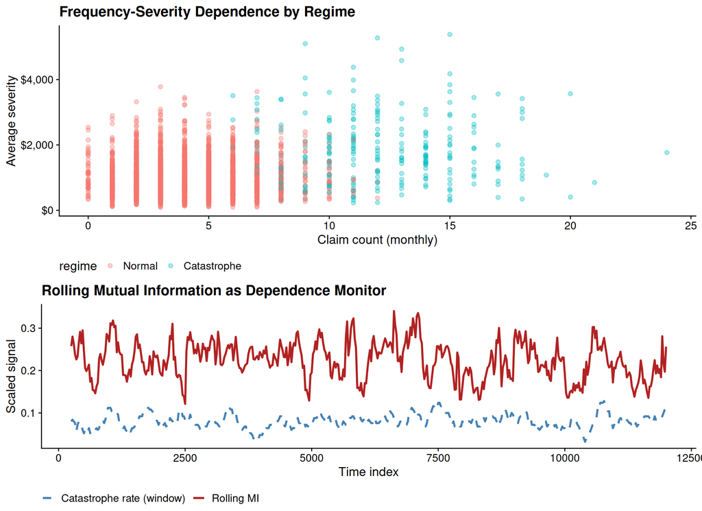

Latent catastrophe regime induces stronger dependence between frequency and severity than Pearson alone suggests.

```r
risk_tbl <- tibble(freq = freq, sev = sev, regime = factor(cat_regime, labels = c("Normal", "Catastrophe")))

p_scatter <- risk_tbl |>
  sample_n(3000) |>
  ggplot(aes(x = freq, y = sev, colour = regime)) +
  geom_point(alpha = 0.35) +
  scale_y_continuous(labels = label_dollar()) +
  labs(
    title = "Frequency-Severity Dependence by Regime",
    x     = "Claim count (monthly)",
    y     = "Average severity"
  ) +
  theme(legend.position = "bottom")

# rolling MI as an early warning signal
roll_window <- 250
roll_idx <- seq(roll_window, n_months, by = 25)

rolling_tbl <- map_dfr(roll_idx, function(i) {
  idx <- (i - roll_window + 1):i
  tibble(
    t = i,
    mi_roll = estimate_mi_histogram(freq[idx], sev[idx], n_bins_x = 10, n_bins_y = 10),
    cat_rate = mean(cat_regime[idx])
  )
})

p_roll <- ggplot(rolling_tbl, aes(x = t)) +
  geom_line(aes(y = mi_roll, colour = "Rolling MI"), linewidth = 1.1) +
  geom_line(aes(y = cat_rate, colour = "Catastrophe rate (window)"), linewidth = 1.1, linetype = "dashed") +
  scale_colour_manual(values = c("Rolling MI" = "firebrick", "Catastrophe rate (window)" = "steelblue")) +
  labs(
    title = "Rolling Mutual Information as Dependence Monitor",
    x     = "Time index",
    y     = "Scaled signal",
    colour = NULL
  ) +
  theme(legend.position = "bottom")

plot_grid(p_scatter, p_roll, ncol = 1, rel_heights = c(1.2, 1))
```

### 5.1.1 Why This Matters in Practice

This pattern is common in real portfolios: dependence intensifies in stress regimes. Monitoring MI alongside linear metrics can provide earlier warning of joint-risk buildup than correlation alone.

## 5.2 Pricing with Wrong vs. Right Regime Model (KL Penalty)

Suppose pricing assumes a single benign regime distribution while the real world is a mixture. KL divergence quantifies model misspecification cost.

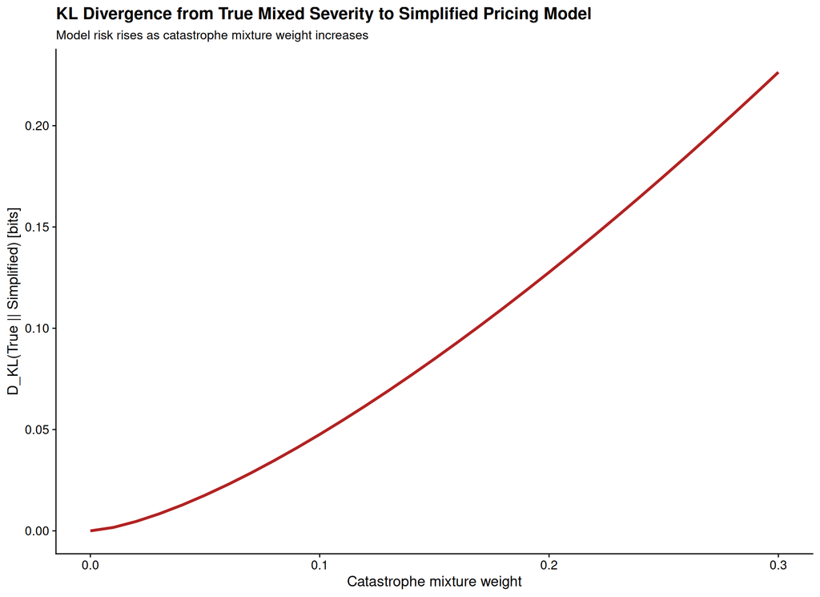

KL divergence between true mixed severity and simplified single-regime model grows quickly as catastrophe weight increases.

```r
x_grid <- seq(0.001, 10000, by = 10)

severity_mixture <- function(w_cat) {
  f <- (1 - w_cat) * dgamma(x_grid, shape = 3.5, rate = 0.0035) +
       w_cat       * dgamma(x_grid, shape = 2.2, rate = 0.0012)
  f / sum(f)
}

severity_single <- dgamma(x_grid, shape = 3.5, rate = 0.0035)
severity_single <- severity_single / sum(severity_single)

w_seq <- seq(0, 0.30, by = 0.01)

kl_tbl <- tibble(
  cat_weight = w_seq,
  kl_bits = map_dbl(w_seq, ~kl_divergence(severity_mixture(.x), severity_single))
)

ggplot(kl_tbl, aes(x = cat_weight, y = kl_bits)) +
  geom_line(colour = "firebrick", linewidth = 1.3) +
  labs(
    title = "KL Divergence from True Mixed Severity to Simplified Pricing Model",
    subtitle = "Model risk rises as catastrophe mixture weight increases",
    x = "Catastrophe mixture weight",
    y = "D_KL(True || Simplified) [bits]"
  )
```

### 5.2.1 Why This Matters in Practice

KL here acts as a model-risk indicator:

- Rising KL means the simplified pricing view is becoming increasingly costly in information terms.
- It can support governance thresholds for model refresh triggers.
- It provides a quantitative bridge between distribution drift and pricing risk.

# 6 Cross-Domain Sampler

## 6.1 Genomics: Sequence Logo Entropy

At each DNA position, entropy quantifies conservation. Low entropy means strong evolutionary pressure (highly conserved base), high entropy means variability.

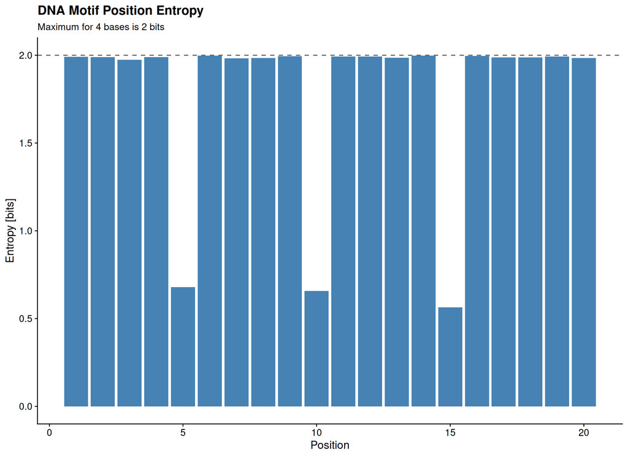

Per-position entropy across a toy DNA motif alignment. Conserved motifs stand out via low entropy.

```r
set.seed(77)

n_seq <- 250
positions <- 20
bases <- c("A", "C", "G", "T")

# Build synthetic motif: conserved positions at 5, 10, 15
make_probs <- function(pos) {
  if (pos %in% c(5, 10, 15)) c(0.9, 0.03, 0.04, 0.03) else c(0.25, 0.25, 0.25, 0.25)
}

alignment <- map_dfc(seq_len(positions), function(pos) {
  tibble(!!paste0("p", pos) := sample(bases, size = n_seq, replace = TRUE, prob = make_probs(pos)))
})

pos_entropy <- map_dbl(seq_len(positions), function(pos) {
  counts <- table(alignment[[pos]])
  entropy_from_counts(counts)
})

entropy_tbl <- tibble(position = seq_len(positions), entropy_bits = pos_entropy)

ggplot(entropy_tbl, aes(x = position, y = entropy_bits)) +
  geom_col(fill = "steelblue") +
  geom_hline(yintercept = 2, linetype = "dashed", colour = "grey40") +
  labs(
    title = "DNA Motif Position Entropy",
    subtitle = "Maximum for 4 bases is 2 bits",
    x = "Position",
    y = "Entropy [bits]"
  )
```

### 6.1.1 Why This Matters in Practice

Per-position entropy is a compact conservation score:

- Low-entropy sites are candidates for functional importance.
- High-entropy sites are likely flexible/background positions.
- The same logic generalizes to other sequence-like domains (clickstreams, event logs, protocol traces).

## 6.2 NLP: Next-Token Uncertainty and Perplexity

Language-model quality is often reported with cross-entropy and perplexity:

$$\text{Perplexity} = 2^{H(P, Q)}$$

Lower perplexity implies better predictive modelling.

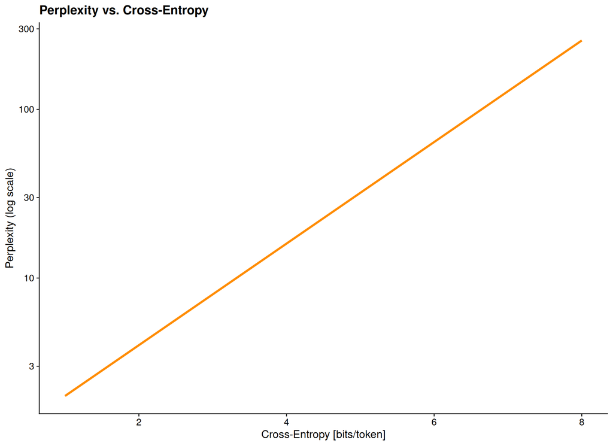

Perplexity grows exponentially with cross-entropy. Small improvements in cross-entropy can produce meaningful perplexity gains.

```r
ce_seq <- seq(1, 8, by = 0.05)

perp_tbl <- tibble(
  cross_entropy_bits = ce_seq,
  perplexity = 2^ce_seq
)

ggplot(perp_tbl, aes(x = cross_entropy_bits, y = perplexity)) +
  geom_line(colour = "darkorange", linewidth = 1.3) +
  scale_y_log10(labels = label_number(accuracy = 1)) +
  labs(
    title = "Perplexity vs. Cross-Entropy",
    x = "Cross-Entropy [bits/token]",
    y = "Perplexity (log scale)"
  )
```

### 6.2.1 Why This Matters in Practice

Perplexity translates abstract information units into intuitive branching difficulty:

- A model with perplexity 20 behaves as if it is choosing among about 20 plausible next tokens on average.
- Small cross-entropy improvements can yield meaningful perplexity gains.
- This is why careful probability calibration remains valuable even when top-1 predictions look similar.

# 7 Summary

Part 2 covered the operational heart of information theory:

- **Source coding**: entropy sets the fundamental lower bound for lossless compression.
- **Huffman coding**: practical prefix coding that approaches the entropy bound.
- **Noisy channels**: capacity defines what reliable transmission rates are fundamentally achievable.
- **BSC/BEC/AWGN**: canonical channels with explicit capacity formulas.
- **Machine learning**: entropy, information gain, cross-entropy, and KL are built into modern algorithms.
- **Risk modelling**: MI and KL provide dependence diagnostics and misspecification penalties beyond linear correlation.
- **Cross-domain relevance**: genomics and NLP show the same core concepts at work in very different systems.

Information theory is powerful because it separates *domain details* from *structural limits*: it gives universal rules about uncertainty, compression, and communication that apply almost everywhere.